# Lab 16: Survival Analysis

```r
# Packages
library(survival)
library(ggplot2)
library(rstpm2)
library(haven)
library(eha)
library(skimr)
library(biostat3)
library(broom)
library(pammtools)
library(ggfortify)
library(dplyr)
```

### L1

Import the data into R. Since we will focus on the clinical data in this lab, you can also create a new data frame including only this subset (aml). Familiarise yourself with the data.

```r
# Load data
# Need to adjust the path to match the location of data on your computer
load(file = "BeatAML2_clean.Rdata")
# Remove other data frames
rm(drug_data, meta_data, meta_dataDictionary, rnaCounts, rnaLog2CPM, rnaNorm, geneMap)
# We will only use clinical data in this lab, create new dataframe
aml <- clinical_data
```

```r
# Data cleaning for simplicity
# Drop missing values in the variables we will work with
library(dplyr)
aml <- filter(aml, !is.na(ageAtDiagnosis))
aml <- filter(aml, ageAtDiagnosis != 0)
aml <- aml |> filter(vitalStatus != "Unknown")
# same as:
# aml <- filter(aml, vitalStatus != "Unknown")
```

```r
head(aml)
```

|  | sample | cohort | consensus_sex | ageAtDiagnosis | specimenType | wbcCount | albumin | creatinine | hematocrit | hemoglobin | vitalStatus | overallSurvival | responseToInductionTx | consensusAMLFusions | ELN2017 | fabBlastMorphology | FLT3-ITD | NPM1 | RUNX1 | ASXL1 | TP53 |
| --- | --- | --- | --- | --- | --- | --- | --- | --- | --- | --- | --- | --- | --- | --- | --- | --- | --- | --- | --- | --- | --- |
| 1 | BA2409 | Waves1+2 | Female | 71 | Bone Marrow Aspirate | 14.9 | 3.0 | 0.85 | 21.9 | 7.6 | Dead | 397 | Refractory | NA | Intermediate | M5 | negative | negative | FALSE | FALSE | FALSE |
| 2 | BA2496 | Waves1+2 | Male | 70 | Bone Marrow Aspirate | 21.0 | 3.6 | 1.18 | 28.7 | 9.7 | Dead | 311 | NA | NA | MissingMutations | M4 | positive | negative | FALSE | FALSE | FALSE |
| 3 | BA3037 | Waves1+2 | Female | 55 | Bone Marrow Aspirate | 17.9 | 3.4 | 0.88 | 28.2 | 9.6 | Dead | 707 | Complete Response | NA | FavorableOrIntermediate | M1 | positive | positive | FALSE | FALSE | FALSE |
| 4 | BA2865 | Waves1+2 | Female | 50 | Bone Marrow Aspirate | 84.1 | 2.8 | 0.86 | 26.4 | 9.1 | Alive | 3129 | Complete Response | NA | Favorable | M0 | negative | positive | FALSE | FALSE | FALSE |
| 5 | BA2286 | Waves1+2 | Male | 61 | Bone Marrow Aspirate | 16.5 | 3.2 | 1.05 | 26.4 | 8.8 | Alive | 33 | Refractory | NA | Intermediate | M2 | negative | negative | FALSE | FALSE | FALSE |
| 6 | BA2488 | Waves1+2 | Female | 83 | Bone Marrow Aspirate | 6.0 | 3.7 | 0.70 | 23.4 | 8.1 | Alive | 2806 | Complete Response | PML-RARA | Favorable | M3 | negative | negative | FALSE | FALSE | FALSE |

```r
# some descriptives
summary(aml)
```

```
    sample             cohort          consensus_sex      ageAtDiagnosis
 Length:434         Length:434         Length:434         Min.   : 2.00
 Class :character   Class :character   Class :character   1st Qu.:46.00
 Mode  :character   Mode  :character   Mode  :character   Median :61.00
                                                          Mean   :56.49
                                                          3rd Qu.:71.00
                                                          Max.   :88.00

 specimenType          wbcCount          albumin        creatinine
 Length:434         Min.   :  0.500   Min.   :1.700   Min.   :0.240
 Class :character   1st Qu.:  8.645   1st Qu.:2.800   1st Qu.:0.700
 Mode  :character   Median : 24.900   Median :3.100   Median :0.850
                    Mean   : 44.594   Mean   :3.142   Mean   :0.986
                    3rd Qu.: 62.615   3rd Qu.:3.500   3rd Qu.:1.065
                    Max.   :427.460   Max.   :4.800   Max.   :6.730
                    NA's   :63        NA's   :165     NA's   :175
   hematocrit      hemoglobin     vitalStatus        overallSurvival
 Min.   :11.10   Min.   : 3.700   Length:434         Min.   :   1.0
 1st Qu.:21.50   1st Qu.: 7.125   Class :character   1st Qu.:  72.5
 Median :24.80   Median : 8.200   Mode  :character   Median : 292.0
 Mean   :25.48   Mean   : 8.488                      Mean   : 608.8
 3rd Qu.:28.80   3rd Qu.: 9.500                      3rd Qu.: 882.5
 Max.   :48.80   Max.   :16.100                      Max.   :3129.0
 NA's   :149     NA's   :144
 responseToInductionTx consensusAMLFusions   ELN2017          fabBlastMorphology
 Length:434            Length:434          Length:434         Length:434
 Class :character      Class :character    Class :character   Class :character
 Mode  :character      Mode  :character    Mode  :character   Mode  :character




   FLT3-ITD             NPM1             RUNX1           ASXL1
 Length:434         Length:434         Mode :logical   Mode :logical
 Class :character   Class :character   FALSE:384       FALSE:391
 Mode  :character   Mode  :character   TRUE :50        TRUE :43




    TP53
 Mode :logical
 FALSE:395
 TRUE :39
```

```r
# more descriptive summary
library(skimr)
skim(aml)
```

```
── Data Summary ────────────────────────
                           Values
Name                       aml
Number of rows             434
Number of columns          21
_______________________
Column type frequency:
  character                11
  logical                  3
  numeric                  7
________________________
Group variables            None
```

|  | skim_variable | n_missing | complete_rate | min | max | empty | n_unique | whitespace |
| --- | --- | --- | --- | --- | --- | --- | --- | --- |
| 1 | sample | 0 | 1.0000000 | 6 | 6 | 0 | 434 | 0 |
| 2 | cohort | 0 | 1.0000000 | 4 | 8 | 0 | 3 | 0 |
| 3 | consensus_sex | 0 | 1.0000000 | 4 | 6 | 0 | 2 | 0 |
| 4 | specimenType | 0 | 1.0000000 | 13 | 20 | 0 | 3 | 0 |
| 5 | vitalStatus | 0 | 1.0000000 | 4 | 5 | 0 | 2 | 0 |
| 6 | responseToInductionTx | 84 | 0.8064516 | 7 | 19 | 0 | 6 | 0 |
| 7 | consensusAMLFusions | 330 | 0.2396313 | 8 | 13 | 0 | 7 | 0 |
| 8 | ELN2017 | 0 | 1.0000000 | 7 | 23 | 0 | 7 | 0 |
| 9 | fabBlastMorphology | 167 | 0.6152074 | 2 | 5 | 0 | 13 | 0 |
| 10 | FLT3-ITD | 0 | 1.0000000 | 8 | 8 | 0 | 2 | 0 |

[output cut: 1 more lines]

|  | skim_variable | n_missing | complete_rate | mean | count |
| --- | --- | --- | --- | --- | --- |
| 1 | RUNX1 | 0 | 1 | 0.11520737 | FAL: 384, TRU: 50 |
| 2 | ASXL1 | 0 | 1 | 0.09907834 | FAL: 391, TRU: 43 |
| 3 | TP53 | 0 | 1 | 0.08986175 | FAL: 395, TRU: 39 |

|  | skim_variable | n_missing | complete_rate | mean | sd | p0 | p25 | p50 | p75 | p100 | hist |
| --- | --- | --- | --- | --- | --- | --- | --- | --- | --- | --- | --- |
| 1 | ageAtDiagnosis | 0 | 1.0000000 | 56.4930876 | 18.0994481 | 2.00 | 46.000 | 61.00 | 71.000 | 88.00 | ▁▃▃▇▅ |
| 2 | wbcCount | 63 | 0.8548387 | 44.5939623 | 53.3417465 | 0.50 | 8.645 | 24.90 | 62.615 | 427.46 | ▇▁▁▁▁ |
| 3 | albumin | 165 | 0.6198157 | 3.1420074 | 0.5981792 | 1.70 | 2.800 | 3.10 | 3.500 | 4.80 | ▂▆▇▃▁ |
| 4 | creatinine | 175 | 0.5967742 | 0.9860232 | 0.6563931 | 0.24 | 0.700 | 0.85 | 1.065 | 6.73 | ▇▁▁▁▁ |
| 5 | hematocrit | 149 | 0.6566820 | 25.4807018 | 5.7964547 | 11.10 | 21.500 | 24.80 | 28.800 | 48.80 | ▁▇▅▁▁ |
| 6 | hemoglobin | 144 | 0.6682028 | 8.4882759 | 1.9647588 | 3.70 | 7.125 | 8.20 | 9.500 | 16.10 | ▁▇▅▁▁ |
| 7 | overallSurvival | 0 | 1.0000000 | 608.8410138 | 727.8332138 | 1.00 | 72.500 | 292.00 | 882.500 | 3129.00 | ▇▂▁▁▁ |

We are interested in overall survival for AML patients. The patient vital status at the date of most recent follow-up is given by variable vitalStatus and the number of days between diagnosis date and last followup date found when determining vital status is given by variable overallSurvival

```r
# outcome of interest
table(aml$vitalStatus, exclude = NULL)
prop.table(table(aml$vitalStatus))
```

```r
# time to event
summary(aml$overallSurvival)
aml <- mutate(aml, overallSurvivalyears = overallSurvival / 365.25)
summary(aml$overallSurvivalyears)
```

1. What is the event and what is the time at risk? The event is death and the time at risk is the time from diagnosis to death or last follow-up.
2. What is the proportion of AML patients that die? Give descriptive for the overall survival time? The proportion of AML patients that die is 0.546. The median overall survival time is 0.8 years, with a range of 0.003 to 8.567 years.

Create a variable representing the survival time object. Print the new object and compare with the survival time and the event indicator variables. Make sure that the survival time object has been defined properly.

```r
aml <- aml |>
  mutate(s = Surv(time = overallSurvivalyears,
                  event = (vitalStatus == "Dead")))
aml |> select(overallSurvivalyears, vitalStatus, s) |> head()
```

### L2

Estimate the Kaplan-Meier survival probability for the AML patients. To do so, we need the survival package that was already loaded in the previous question.

```r
library(survival)
# Kaplan-Meier
km <- survfit(s ~ 1, data = aml)
# Print the estimate at each failure time
summary(km)
# Obtain a summary for the Kaplan-Meier estimate
km
# Survival estimates at specific time since diagnosis
summary(km, times = c(0, 1, 5))
```

[output not shown]

1. Calculate the Kaplan-Meier survival probability estimates at the first 2 failure times by hand. Is this the same as the one estimated above? Yes, the estimates are the same.
2. What is the median survival and what is its interpretation? The median survival is 1.26 years. This means that 50% of the patients are expected to survive for at least 1.26 years after diagnosis.
3. What is the survival probability at 0, 1 and 5 years after diagnosis? The survival probability at 0, 1 and 5 years after diagnosis is 1, 0.54, and 0.35, respectively.

L3 Plot the Kaplan-Meier estimate. The Kaplan-Meier survival estimate is a step function that changes at every distinct survival time, but does not change at censoring times.

```r
library(broom)
library(pammtools)
lab_km <- ggplot(tidy(km), aes(x = time, y = estimate)) +
geom_stepribbon(aes(ymin = conf.low, ymax = conf.high), alpha = 0.1) +
geom_step() +
theme_bw(base_size = 12) +
coord_cartesian(ylim = c(0, 1)) +
labs(x = "Time (years)", y = expression(S[KM](t)))
lab_km
```

[output not shown]

Why does the survival curve not reach zero? The survival curve does not reach zero because some patients are still alive at the end of the study period.

### L4 Estimate the survival probability separately for males and females.

```r
# Transform sex variable to factor
aml <- aml |>
mutate(consensus_sex = factor(consensus_sex, levels = c("Female", "Male")))
# Estimate Kaplan-Meier survival by sex
km2 <- survfit(s ~ consensus_sex, data = aml)
summary(km2)
```

Then plot the survival curves.

```r
lab_km2 <- ggplot(tidy(km2), aes(x = time, y = estimate)) +
geom_stepribbon(aes(ymin = conf.low, ymax = conf.high, fill = strata),
alpha = 0.1) +
geom_step(aes(color = strata)) +
scale_color_manual(values = c(1, 2)) +
scale_fill_manual(values = c(1, 2)) +
theme_bw(base_size = 12) +
theme(legend.position = "top") +
coord_cartesian(ylim = c(0, 1)) +
labs(x = "Time (years)", y = expression(S[KM](t)), color = "", fill = "")
lab_km2
```

[output not shown]

1. Who has a better survival, males or females? Female patients have a better survival.
2. Based on the plot, what is approximately the median survival for males and females? Confirm your answer by printing km2. The median survival for males is 0.8 years and the median survival for females is 2.5 years.

```r
km2
```

3. Based on the Kaplan-Meier curves, what can you say about the hazard functions? How would you expect them to look like?

The hazard function is the instantaneous risk of death at a given time. The hazard function is the slope of the survival curve. The hazard function is higher when the survival curve is steeper. The hazard function is lower when the survival curve is flatter. The hazard function of male patients is higher than that of female patients at the beginning.

• Once you have answered on the question 3, plot the hazard functions by sex using the following code. Was your previous response correct?

```r
library(biostat3)
library(muhaz)
bh_bysex <- muhaz2(s ~ consensus_sex, data = aml)
bh_bysex <- bind_rows(
data.frame(time = bh_bysex$`consensus_sex=Female`$est.grid,
h = bh_bysex$`consensus_sex=Female`$haz.est, consensus_sex = "Female"),
data.frame(time = bh_bysex$`consensus_sex=Male`$est.grid,
h = bh_bysex$`consensus_sex=Male`$haz.est, consensus_sex = "Male")
) |>
ggplot(aes(x = time, y = h, linetype = consensus_sex)) +
geom_line() +
theme_bw(base_size = 12) +
theme(legend.position = "top") +
labs(x = "Time (years)", y = "Hazard", linetype = "")
bh_bysex
```

[output not shown]

### L5 Perform a Log-rank test to check whether the survival curves by sex are statistically different.

```r
survdiff(s ~ consensus_sex, data = aml, rho = 0)
```

[output not shown]

Are the survival probabilities by sex statistically different? Yes, the survival probabilities by sex are statistically different (p-value < 0.05).

The Log-rank test gives equal weight to all time points. As follow-up time increases there will be fewer individuals left event-free. The Wilcoxon method can also be applied and this gives more weight to events at early time points.

```r
survdiff(s ~ consensus_sex, data = aml, rho = 1)
```

Does the Wilcoxon test agree with the Log-rank test? Yes, the Wilcoxon test agrees with the Log-rank test (p-value < 0.05).

### L6

Next we want to explore whether the survival differences by sex are due to differences in the age at diagnosis. This can be done by performing a stratified log-rank test. Since age is a continuous variable we need to turn it into a categorical variable first.

```r
summary(aml$ageAtDiagnosis)
# create two categories for age at diagnosis: below or above 65 years old
aml$ageAtDiagnosiscat<-cut(aml$ageAtDiagnosis, c(0,65,100))
survdiff(s ~ consensus_sex + strata(ageAtDiagnosiscat), data = aml)
```

1. Do differences exist even when we stratify by age at diagnosis? Yes, differences exist even when we stratify by age at diagnosis (p-value < 0.05).
2. What are potential limitations of the the log-rank test? The log-rank test assumes that the hazard functions are proportional. The log-rank test is sensitive to the choice of time points. The log-rank test does not account for covariates.

### L7 Fit a Cox proportional hazards model to investigate the effect of sex on survival of AML patients.

```r
cox <- coxph(s ~ consensus_sex, data = aml)
summary(cox)
```

[output not shown]

1. Write down the model formulation. The Cox proportional hazards model is given by: h(t) = h0(t) * exp(β) where h(t) is the hazard function at time t, h0(t) is the baseline hazard function at time t, and β is the coefficient for association regression. The model is log-linear in the hazard function.
2. What is the estimate for the hazard ratio of sex and what is the interpretation? The estimate for the hazard ratio of sex is 1.5309. This means that the mortality rate of male patients is 53.09% higher than female patients.

### L8 Obtain the estimated survival curves for both values of sex, and compare the results with the

Kaplan-Meier estimates.

First, we obtain predictions of the survival function using the Cox model and the Kaplan-Meier estimator:

```r
nd <- data.frame(consensus_sex = c("Male", "Female"))
cox.surv <- survfit(cox, newdata = nd)
km.surv <- survfit(s ~ consensus_sex, data = aml)
```

Then, we use the tidy function from the broom package to extract the estimated survival as tidy datasets:

```r
cox.surv.data <- tidy(cox.surv)
km.surv.data <- tidy(km.surv)
```

Finally, we plot the four distinct estimated survival curves:

```r
plotdata <- bind_rows(
  cox.surv.data |>
    mutate(time,
      Survival = estimate.1,
      Sex = nd$consensus_sex[1],
      model = "Cox",
      .keep = "none"
    ),
  cox.surv.data |>
    mutate(time,
      Survival = estimate.2,
      Sex = nd$consensus_sex[2],
      model = "Cox",
      .keep = "none"
    ),
  km.surv.data |>
    mutate(time,
      Survival = estimate,
      Sex = sub("consensus_sex=", "", strata),
      model = "KM",
      .keep = "none"
    )
)
lab_kmcox <- ggplot(plotdata, aes(time, Survival, colour = Sex, linetype = model)) +
  geom_step() +
  theme_bw(base_size = 12) +
  theme(legend.position = "top") +
  coord_cartesian(ylim = c(0, 1)) +
  labs(x = "Time", y = "Survival", linetype = "Model")
lab_kmcox
```

[output not shown]

1. Is there a good agreement between the estimates obtained from the Cox model and the Kaplan- Meier? Yes, there is a good agreement between the estimates obtained from the Cox model and the Kaplan-Meier.
2. What are the different assumptions made between the two approaches? The Cox model assumes that the hazard ratio is constant over time. The Kaplan-Meier method does not make any assumptions about the hazard function.
3. **Cox Proportional Hazards Model**:
   - Assumes **proportional hazards**: The hazard ratios between groups are constant over time.
   - Provides survival estimates adjusted for covariates (e.g., other predictors like age).
   - Model-based approach that allows extrapolation beyond observed data.
4. **Kaplan-Meier Estimator**:
   - Makes no assumptions about the hazard function or proportionality.
   - A purely **non-parametric method**, relying on observed event times.
   - Provides unadjusted survival estimates for each group (e.g., Male and Female) without considering additional covariates.

### L9 Now fit a Cox proportional hazards model to investigate the effect of sex on survival of AML

patients while adjusting for age at diagnosis.

```r
cox2 <- coxph(s ~ consensus_sex + ageAtDiagnosis , data = aml)
summary(cox2)
```

```
Call:
coxph(formula = s ~ consensus_sex + ageAtDiagnosis, data = aml)

  n= 434, number of events= 237

                     coef exp(coef) se(coef)     z Pr(>|z|)
consensus_sexMale 0.35227   1.42230  0.13417 2.626  0.00865 **
ageAtDiagnosis    0.04217   1.04307  0.00464 9.089  < 2e-16 ***
---
Signif. codes:  0 ‘***’ 0.001 ‘**’ 0.01 ‘*’ 0.05 ‘.’ 0.1 ‘ ’ 1

                  exp(coef) exp(-coef) lower .95 upper .95
consensus_sexMale     1.422     0.7031     1.093     1.850
ageAtDiagnosis        1.043     0.9587     1.034     1.053

Concordance= 0.705  (se = 0.016 )
Likelihood ratio test= 113.3  on 2 df,   p=<2e-16
Wald test            = 93.07  on 2 df,   p=<2e-16
Score (logrank) test = 99.5  on 2 df,   p=<2e-16
```

1. Write down the model formulation.

h(t∣consensus_sex,ageAtDiagnosis)=h0(t)exp(β1consensu_sex+β2ageAtDiagnosis)

2. What is the estimate for the hazard ratio of sex and what is the interpretation? HR for male is 1.422. That means that the hazard for male is 42.2% higher than females.
3. Is age at diagnosis statistical significant? Yes, age at diagnosis is statistically significant (p-value < 0.05).

### L10

Extend the previous model to include a time-dependent effect for sex.

```r
cox.tvc <-coxph(s ~ consensus_sex + tt(consensus_sex) + ageAtDiagnosis,
data = aml, tt = function(x, t, ...) (x == "Male") * log(t))
summary(cox.tvc)
```

```
Call:
coxph(formula = s ~ consensus_sex + tt(consensus_sex) + ageAtDiagnosis,
    data = aml, tt = function(x, t, ...) (x == "Male") * log(t))

  n= 434, number of events= 237

                      coef exp(coef) se(coef)     z Pr(>|z|)
consensus_sexMale 0.482618  1.620310 0.164057 2.942  0.00326 **
tt(consensus_sex) 0.114902  1.121763 0.082101 1.400  0.16166
ageAtDiagnosis    0.042409  1.043321 0.004649 9.123  < 2e-16 ***
---
Signif. codes:  0 ‘***’ 0.001 ‘**’ 0.01 ‘*’ 0.05 ‘.’ 0.1 ‘ ’ 1

                  exp(coef) exp(-coef) lower .95 upper .95
consensus_sexMale     1.620     0.6172     1.175     2.235
tt(consensus_sex)     1.122     0.8915     0.955     1.318
ageAtDiagnosis        1.043     0.9585     1.034     1.053

Concordance= 0.707  (se = 0.016 )
Likelihood ratio test= 115.2  on 3 df,   p=<2e-16
Wald test            = 94.83  on 3 df,   p=<2e-16
Score (logrank) test = 101.5  on 3 df,   p=<2e-16
```

```r
# Likelihood ratio test comparing the model with interaction to model
# with no interaction
library(lmtest)
lrtest(cox.tvc,cox2)
```

```
Likelihood ratio test

Model 1: s ~ consensus_sex + tt(consensus_sex) + ageAtDiagnosis
Model 2: s ~ consensus_sex + ageAtDiagnosis
  #Df  LogLik Df Chisq Pr(>Chisq)
1   3 -1247.9
2   2 -1248.9 -1 1.944     0.1632
```

### L11

Plot the time-varying HR for sex from the model fitted in L10.

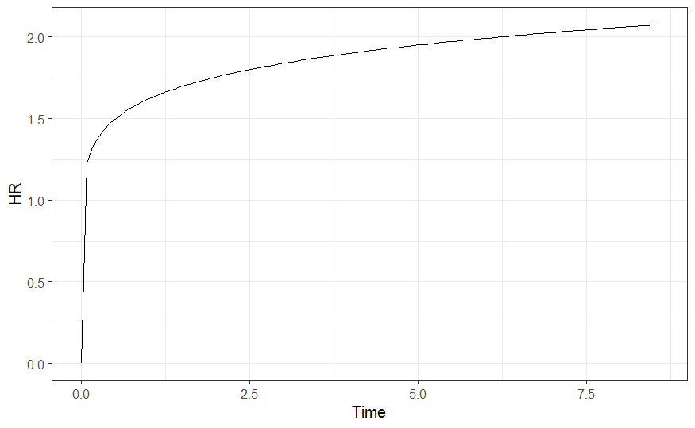

```r
hr <- function(time) exp(coef(cox.tvc)[1] + coef(cox.tvc)[2] * log(time))
nd <- data.frame(time = seq(0, max(aml$overallSurvivalyears), length.out = 100))
nd$hr <- hr(nd$time)
lab_hr <- ggplot(nd, aes(x = time, y = hr)) +
geom_line() +
theme_bw(base_size = 12) +
labs(x = "Time", y = "HR")
lab_hr
```

The HR is increasing with time (males have a higher mortality rate than females). Five years after diagnosis the HR is approximately 1.95 as we estimated in L10.

### L12

Assess the proportional hazards assumption for the covariates included in the cox2 model that was fitted previously.

```r
# Test on Schoenfeld residuals
cox2_sch <- cox.zph(cox2)
cox2_sch
```

```
               chisq df     p
consensus_sex   2.85  1 0.091
ageAtDiagnosis  5.76  1 0.016
GLOBAL          8.74  2 0.013
```

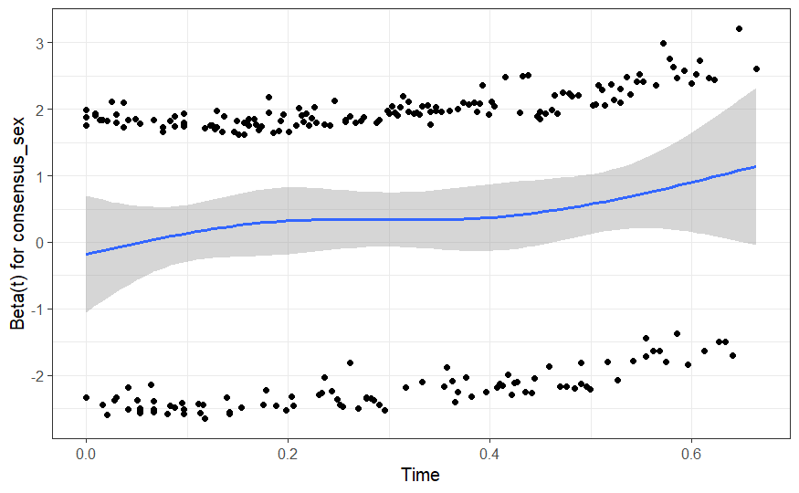

```r
# Plot the residuals for each covariate included in the model
lab_res1 <- ggplot(data.frame(time = cox2_sch$x,
schres = cox2_sch$y[, "consensus_sex"]), aes(x = time, y = schres)) +
geom_point() +
geom_smooth(method = "lm", formula = y ~ ns(x, df = 4, intercept = TRUE)) +
theme_bw(base_size = 12) +
labs(x = "Time", y = "Beta(t) for consensus_sex")
lab_res1
```

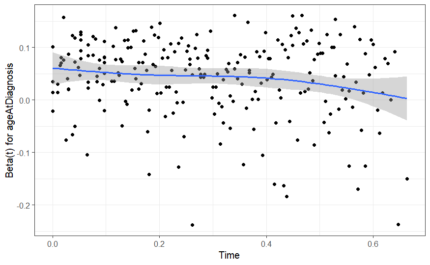

```r
lab_res2 <- ggplot(data.frame(time = cox2_sch$x,
schres = cox2_sch$y[, "ageAtDiagnosis"]), aes(x = time, y = schres)) +
geom_point() +
geom_smooth(method = "lm", formula = y ~ ns(x, df = 4, intercept = TRUE)) +
theme_bw(base_size = 12) +
labs(x = "Time", y = "Beta(t) for ageAtDiagnosis")
lab_res2
```

1. What can you conclude for the PH assumption? The formal test for Schoenfeld residuals indicates that there is violation of the proportional hazards assumption for age at diagnosis and overall in the model. This is also shown at the plot for the residuals of age at diagnosis where a decreasing trend is observed across follow-up (even though the plots are more difficult to interpret).
2. If there are violations with the PH assumption, how can you relax the assumption? Violations to the PH assumption can be addressed by allowing for a time-dependent effect for age at diagnosis in the model. For example,

```r
cox.tvc2 <- coxph(s ~ consensus_sex + ageAtDiagnosis + tt(ageAtDiagnosis),
data = aml, tt = function(x, t, ...) x * log(t))
summary(cox.tvc2)
```

```
Call:
coxph(formula = s ~ consensus_sex + ageAtDiagnosis + tt(ageAtDiagnosis),
    data = aml, tt = function(x, t, ...) x * log(t))

  n= 434, number of events= 237

                        coef exp(coef)  se(coef)      z Pr(>|z|)
consensus_sexMale   0.337085  1.400858  0.134349  2.509   0.0121 *
ageAtDiagnosis      0.035920  1.036573  0.005192  6.918 4.58e-12 ***
tt(ageAtDiagnosis) -0.007225  0.992801  0.003134 -2.305   0.0212 *
---
Signif. codes:  0 ‘***’ 0.001 ‘**’ 0.01 ‘*’ 0.05 ‘.’ 0.1 ‘ ’ 1

                   exp(coef) exp(-coef) lower .95 upper .95
consensus_sexMale     1.4009     0.7138    1.0766    1.8229
ageAtDiagnosis        1.0366     0.9647    1.0261    1.0472
tt(ageAtDiagnosis)    0.9928     1.0073    0.9867    0.9989

Concordance= 0.706  (se = 0.016 )
Likelihood ratio test= 118.8  on 3 df,   p=<2e-16
Wald test            = 95.16  on 3 df,   p=<2e-16
Score (logrank) test = 101.3  on 3 df,   p=<2e-16
```